**2023年度 東京成徳大学 特別講座 資料**  
**東京工科大学コンピュータサイエンス学部**  
**福西広晃**

Pythonの基礎

# データをまとめて管理する方法

- 複数の値を1つの変数で管理しながら、個々の値（`要素`と呼ぶ）を取り出したり、場合によっては変更したりできると便利なことがある。そのためにPythonでは`リスト`、`タプル`、`辞書`、`集合`のデータ型が提供されている
- **本講義では、特に重要な、`リスト`を学習する**

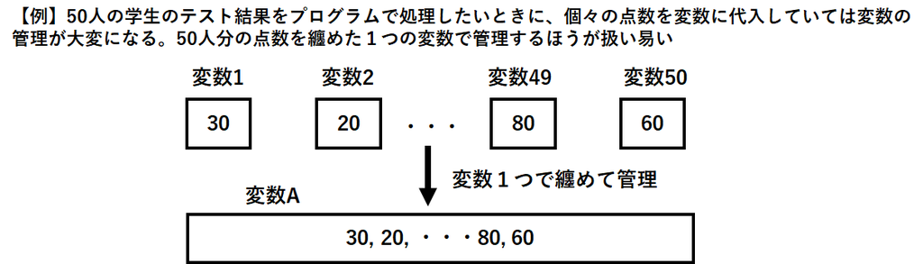

# リストの書き方

- `リスト`は、複数の値をまとめて扱う場合に使用
- `リスト`は、数値や文字列などの基本データ型と並んでPythonでは高頻度で使われるデータ型
- `リスト`は全体を`[]`で囲み、各要素は`カンマ`で区切る
- `リスト`は型の値でも要素として格納することができ、リストの中にリストを格納することも可能である
- `リスト`では`インデックス`(要素番号)を用いて、要素の追加や入れ替えなどが可能

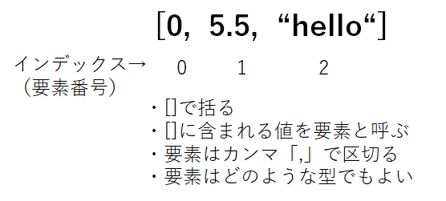

# リストの作成

**5人のテスト結果が90点、85点、75点、95点、80点であったとする**

```python
# リストをlistAの変数に代入
listA = [90, 85, 75, 95, 80]

# 表示
print(listA)
```

```
[90, 85, 75, 95, 80]
```

## 練習1

次の複数の値を纏めたリストを作成してみよう。リストの変数名を`lixtX`とする。

- 112.3, 332.9, 573.8, 552.8, 123.8, 379.1, 332.6, 768.2, 249.8

解答例

```python
# リストをlistXの変数に代入
listX = [112.3, 332.9, 573.8, 552.8, 123.8, 379.1, 332.6, 768.2, 249.8]

# 表示
print(listX)
```

```
[112.3, 332.9, 573.8, 552.8, 123.8, 379.1, 332.6, 768.2, 249.8]
```

# リストの基本情報の取得

## 要素数をカウントする

要素数のカウントには`len関数`を用いる

```
len(リスト)
```

**listAの要素数**

```python
list_num =  len(listA)
print("要素数：",list_num)
```

```
要素数： 5
```

## 要素の最大値、最小値を抽出

- 最大値の抽出には、`max関数`を用いる

  ```
  max(リスト)
  ```

- 最小値の抽出には、`min関数`を用いる

  ```
  min(リスト)
  ```

**listAの最大値と最小値**

```python
list_max = max(listA)
list_min = min(listA)

print("最大値：", list_max)
print("最小値：", list_min)
```

```
最大値： 95
最小値： 75
```

## 練習2

以下にリストlistXに関して、以下の小問を解いてみよう。

```python
listX = [112.3, 332.9, 573.8, 552.8, 123.8, 379.1, 332.6, 768.2, 249.8]
```

(1) listXの要素数を表示してみよう

(2) listXの最大値と最小値の差を計算して表示してみよう

解答例

```python
#(1)
list_num = len(listX)
print("要素数:", list_num)
```

```
要素数: 9
```

```python
#(2)
list_max = max(listX)
list_min = min(listX)
print('最大値－最小値：', list_max-list_min)
```

```
最大値－最小値： 655.9000000000001
```

# リストの要素の操作

## 要素の抽出

- インデックス（要素番号）を指定

  ```
  リスト[インデックス]
  ```

```python
print(listA[0]) # インデックス0を取り出して表示
print(listA[1]) # インデックス1を取り出して表示
print(listA[2]) # インデックス2を取り出して表示
print(listA[3]) # インデックス3を取り出して表示
print(listA[4]) # インデックス4を取り出して表示
```

```
90
85
75
95
80
```

## 要素の置換

- インデックス(要素番号)で置換前の要素を指定し、置換したい値を代入

```python
# 変更前をリストを表示
print("置換前:", listA)

# インデックス0番を置換（最初の学生の点数は70点だった）
listA[0] = 70

# 変更後をリストを表示
print("置換後:", listA)
```

```
置換前: [90, 85, 75, 95, 80]
置換後: [70, 85, 75, 95, 80]
```

## 要素の削除

### インデックスによる要素の削除

```
リスト.pop(削除する要素のインデックス)
```

```python
# 削除前のリストを表示
listA = [90, 85, 75, 95, 80] # 5人の点数
print("削除前:", listA)

# インデックス(要素番号)0番目を削除
listA.pop(0)

# 削除後のリストを表示
print("削除後:", listA)
```

```
削除前: [90, 85, 75, 95, 80]
削除後: [85, 75, 95, 80]
```

### 特定の値の要素の削除

```
リスト.remove(削除する要素)`
```

- リストの中に該当する要素が見つからなかった場合はエラー(ValueError)が発生する
- 削除される要素は「最初に該当したもの」のため、同じ値が2回以上出てくると最初に出る要素だけ削除される

```python
# 削除前のリストを表示
listC = [90, 85, 75, 95, 85] # 5人の点数
print("削除前:", listC)

# 1つ目の85点を削除
listC.remove(85)

# 削除後のリストを表示
print("1回目削除後:", listC)

# 2つ目の85点を削除
listC.remove(85)

# 削除後のリストを表示
print("2回目削除後:", listC)
```

```
削除前: [90, 85, 75, 95, 85]
1回目削除後: [90, 75, 95, 85]
2回目削除後: [90, 75, 95]
```

## 練習3

以下にリストlistXに関して、以下の小問を解いてみよう。

```python
listX = [112.3, 332.9, 573.8, 552.8, 123.8, 379.1, 332.6, 768.2, 249.8]
```

(1) listXの左から4番目の要素を表示してみよう

(2) listXの左から6番目の要素を7.5に変更した後、listXを表示して確認してみよう。

(3) listXの左から2番目の要素を削除した後、listXを表示して確認してみよう。左から2番目のインデックスは1であることに注意しよう。

(4) listXの249.8の要素を削除した後、listXを表示して確認してみよう。

解答例

```python
#(1)
print(listX[3])
```

```
552.8
```

```python
#(2)
listX[5] = 7.5
print(listX)
```

```
[112.3, 332.9, 573.8, 552.8, 123.8, 7.5, 332.6, 768.2, 249.8]
```

```python
#(3)
listX.pop(1)
print(listX)
```

```
[112.3, 573.8, 552.8, 123.8, 7.5, 332.6, 768.2, 249.8]
```

```python
#(4)
listX.remove(249.8)
print(listX)
```

```
[112.3, 573.8, 552.8, 123.8, 7.5, 332.6, 768.2]
```

# リストのサイズの操作

## 複数のリストの結合

`リストA = リストB + リストC`

**最初のテストの受験者5人の結果は、90点、85点、75点、95点、80点であったとする。その後、新たに4人がテストを受験して、70点, 80点, 75点, 90点であった。さらに、2人がテストを受験して85点、95点であった。**

```python
listA = [90, 85, 75, 95, 80]
listB = [70, 80, 75, 90]
listC = [85, 95]

# listAとlistBを結合させてlistDを作成
listD = listA + listB

# リストを出力
print("1回目の結合：", listD)

# listDに対してlistCを結合させてlistDを拡張
listD = listD + listC     # listD += listC でも可

# リストを出力
print("2回目の結合：", listD)
```

```
1回目の結合： [90, 85, 75, 95, 80, 70, 80, 75, 90]
2回目の結合： [90, 85, 75, 95, 80, 70, 80, 75, 90, 85, 95]
```

## 要素の追加

`リスト.append(値)`

```python
# 要素追加前
listA = [90, 80, 70, 60, 50]
print("要素追加前", listA)

# 要素追加
listA.append(40)
print("要素追加後", listA)
```

```
要素追加前 [90, 80, 70, 60, 50]
要素追加後 [90, 80, 70, 60, 50, 40]
```

## 練習5

以下にリストlistXとlistYがある。

```python
listX = [112.3, 332.9, 573.8, 552.8, 123.8, 379.1, 332.6, 768.2, 249.8]
listY = [44.8, 98.7]
```

(1) listXに対してlistYを結合してlistXを拡張した後、listXを表示してみよう

(2) (1)で得られたlistXに対して`121.5`の値を追加した後、listXを表示してみよう

(3) 結合後のlistXの要素数を表示してみよう

解答例

```python
#(1)
listX = listX + listY
print(listX)
```

```
[112.3, 332.9, 573.8, 552.8, 123.8, 379.1, 332.6, 768.2, 249.8, 44.8, 98.7]
```

```python
#(2)
listX.append(121.5)
print(listX)
```

```
[112.3, 332.9, 573.8, 552.8, 123.8, 379.1, 332.6, 768.2, 249.8, 44.8, 98.7, 121.5]
```

```python
# (3)
list_num = len(listX)
print(list_num)
```

```
12
```

# リストの要素の並び替え

- `sorted関数`を用いる
  - 昇順に並び替え（小→大）

    ```
    sorted(リスト)
    ```

  - 降順に並び替え（大→小）

    ```
    sorted(リスト,reverse=True)`
    ```

## 要素が数値の場合

```python
listD = [90, 85, 75, 95, 80, 70, 80, 75, 90, 85]

# listDを昇順に並び替えてlistEに代入
listE = sorted(listD)
print("昇順に並び替え: ", listE)

# listDを降順に並び替えてlistFに代入
listF = sorted(listD, reverse=True)
print("降順に並び替え: ", listF)
```

```
昇順に並び替え:  [70, 75, 75, 80, 80, 85, 85, 90, 90, 95]
降順に並び替え:  [95, 90, 90, 85, 85, 80, 80, 75, 75, 70]
```

## 要素が文字列の場合(アルファベット順)

```python
listG = ["dog", "cat", "tiger", "bird", "horse"]

listH = sorted(listG)
print("昇順に並び替え: ", listH)

listI = sorted(listG, reverse=True)
print("降順に並び替え: ", listI)
```

```
昇順に並び替え:  ['bird', 'cat', 'dog', 'horse', 'tiger']
降順に並び替え:  ['tiger', 'horse', 'dog', 'cat', 'bird']
```

## 練習4

以下にリストlistXがある。listXの要素を降順に並び替えたlistYを作成して、listYを表示しよう

```python
listX = [112.3, 332.9, 573.8, 552.8, 123.8, 379.1, 332.6, 768.2, 249.8]
```

解答例

```python
listY = sorted(listX,reverse=True)
print(listY)
```

```
[768.2, 573.8, 552.8, 379.1, 332.9, 332.6, 249.8, 123.8, 112.3]
```

# for文によるリストの要素の操作

```
for 要素を代入する変数 in リスト:
    実行する処理
```

要素を1個ずつ変数に代入して繰り返す

**10人のテストの点数の合計値と平均値を計算**

```python
 # 10人のテストの点数を格納
listD = [90, 85, 75, 95, 80, 70, 80, 75, 90, 85]

total = 0               # 合計値の初期値を0とする
for i in listD:        # 要素を１個ずつ取り出して変数eleに代入
    total = total + i  # 要素を足す

# 平均値 = 合計/要素数
average = total / len(listD)  # 平均値をaverageという変数に代入

print("合計値", total)
print("平均値", average)
```

```
合計値 825
平均値 82.5
```

## 練習

以下にリストlistXがある。listXの合計値と平均値を表示してみよう

```python
listX = [112.3, 332.9, 573.8, 552.8, 123.8, 379.1, 332.6, 768.2, 249.8]
```

解答例

```python
total = 0               # 合計値の初期値を0とする
for i in listX:        # 要素を１個ずつ取り出して変数eleに代入
    total = total + i  # 要素を足す

# 平均値 = 合計/要素数
average = total / len(listX)  # 平均値をaverageという変数に代入

print("合計値", total)
print("平均値", average)
```

```
合計値 3425.3
平均値 380.5888888888889
```

# リスト内の要素の統計計算

- 標準ライブラリの`statistics`を用いて、平均、中央値、最頻値、分散、標準偏差を算出できる
  - ライブラリとは、よく使う機能・関数をまとめて、簡単に使えるようにしたもの
  - ライブラリの中身のプログラムがブラックボックスであっても、入力と出力がわかっていれば簡単に実装し、実行することができる
  - Pythonに便利な機能を持つライブラリが多数ある
- 標準ライブラリを使う場合、import文で呼び出す

  ```
  import statistics
  statistics.mean(リスト)      # 平均値
  statistics.median(リスト)    # 中央値(要素を小さい方から大きい方に並べたときの中央の値)
  statistics.mode(リスト)    # 最頻値(最も出現頻度が高い値)
  statistics.pvariance(リスト) # 分散(データのばらつき)
  statistics.pstdev(リスト)    # 標準偏差(分散の平方根)
  ```

**10人のテストの点数の統計量を計算**

```python
import statistics

# 10人の点数
listJ = [90, 85, 75, 95, 80, 70, 75, 90, 80, 75]

mean = statistics.mean(listJ)
print("平均値: ",  mean)

median = statistics.median(listJ)
print("中央値: ", median)

mode = statistics.mode(listJ)
print("最頻値: ", mode)

pvariance = statistics.pvariance(listJ)
print("分散: ", pvariance)

pstdev = statistics.pstdev(listJ)
print("標準偏差: ", pstdev)
```

```
平均値:  81.5
中央値:  80.0
最頻値:  75
分散:  60.25
標準偏差:  7.762087348130012
```

## 練習

10人の身長をまとめたリストとしてhighAがある。平均値、中央値、最頻値、分散、標準偏差を求めてみよう。ただし、statisticsのライブラリをインポートして使用するものとする。

```python
highA = [172, 175, 165, 168, 178, 172, 170, 166, 169, 164]
```

解答例

```python
import statistics

mean = statistics.mean(highA)
print("平均値: ",  mean)

median = statistics.median(highA)
print("中央値: ", median)

mode = statistics.mode(highA)
print("最頻値: ", mode)

var = statistics.pvariance(highA)
print("分散: ", var)

std = statistics.pstdev(highA)
print("標準偏差: ", std)
```

```
平均値:  169.9
中央値:  169.5
最頻値:  172
分散:  17.89
標準偏差:  4.2296571965113205
```

# 総合練習

5人の身長を測った結果、170cm、175cm、160cm、155cm、165cmであったとする

(1) 5人の身長の数値を要素とするリストをhigh1の変数名で作成して、要素数を表示しよう

(2) 左から4番目の人の身長に間違いがあったため150cmに変更して、リストを表示しよう

(3) 新たな5人の身長が180cm、155cm、160cm、165cm、170cmとする。 新たな5人の身長を要素とするリストをhigh2の変数名で作成してみよう。 さらに、high1とhigh2を結合したリストをhigh3の変数名で作成し、表示しよう

(4) 10人の身長を降順で並び替えたリストをhigh4で作成し、表示しよう

(5) for文を利用し、10人の身長の平均値を計算して表示しよう。high4のリストを用いるものとする。

(6) 標準ライブラリのstatisticsを用いて、中央値、最頻値、分散、標準偏差を計算し表示しよう。high4のリストを用いるものとする。

(7) 身長158cm以下の人をhigh4から削除して表示しよう

解答例

```python
# (1)
high1 = [170, 175, 160, 155, 165]
print("要素数: ", len(high1))
```

```
要素数:  5
```

```python
# (2)
high1[3] = 150 # 4番目の人のインデックスは3であることに注意
print("修正:", high1)
```

```
修正: [170, 175, 160, 150, 165]
```

```python
# (3)
high2 = [180, 155, 160, 165, 170]
high3 = high1 + high2
print("結合:", high3)
```

```
結合: [170, 175, 160, 150, 165, 180, 155, 160, 165, 170]
```

```python
# (4)
high4 = sorted(high3, reverse=True)
print("並び替え:", high4)
```

```
並び替え: [180, 175, 170, 170, 165, 165, 160, 160, 155, 150]
```

```python
# (5)
sum = 0
for i in high4:
    sum = sum + i
ave = sum / len(high4)
print("平均", ave)
```

```
平均 165.0
```

```python
# (6)
median = statistics.median(high4)
print("中央値: ", median)

mode = statistics.mode(high4)
print("最頻値: ", mode)

var = statistics.pvariance(high4)
print("分散: ", var)

std = statistics.pstdev(high4)
print("標準偏差: ", std)
```

```
中央値:  165.0
最頻値:  170
分散:  75
標準偏差:  8.660254037844387
```

```python
# (7)
high4.remove(150)
high4.remove(155)
print(high4)
```

```
[180, 175, 170, 170, 165, 165, 160, 160]
```